# Spearman

## Packages

```r
library(psych) #->Deskriptive Statistik
library(ggplot2)#->Diagramme
```

## Roadmap

1. Hypothese
2. Voraussetzungen
3. Grundlegende Konzepte: Was ist Spearman?
4. Grafische Veranschaulichung des Zusammenhangs
5. Deskriptive Statistik
6. Ergebnisse der Korrelationsanalyse
7. Berechnung des Bestimmtheitsmasses
8. Berechnung der Effektstärke
9. Eine Aussage

```r
head(uebung3)
```

| ID | AlterdesMotors | Leistung |
| --- | --- | --- |
| 1 | 9.1 | 42 |
| 2 | 7.6 | 56 |
| 3 | 8.6 | 38 |
| 4 | 5.2 | 50 |
| 5 | 4.7 | 65 |
| 6 | 8.7 | 49 |

# Hypothese

H0: Es gibt keinen linearen Zusammenhang zwischen den ordinalskalierten Variablen Alter und Leistung von Motoren.  
H1: Es gibt einen linearen Zusammenhang zwischen den ordinalskalierten Variablen Alter und Leistung von Motoren.

# Vorraussetzungen

Die Variablen sind mindestens ordinalskaliert -> Beide Variablen sind metrisch.

Die Variablen haben einen linearen Zusammenhang-> siehe Scatterplot

# Grundlegende Konzepte: Was ist Spearman?

Bei der Rangkorrelation wird der ungerichtete lineare Zusammenhang zweier Variable untersucht. “Ungerichtet” bedeutet, dass nicht von einer abhängigen und einer unabhängigen Variable gesprochen wird. Es werden folglich keine kausalen Aussagen gemacht.

Die Rangkorrelation nach Spearman ist das nichtparametrische äquivalent der Korrelationsanalyse nach Bravais-Pearson und wird angewendet, wenn die Voraussetzungen für ein parametrisches Verfahren nicht erfüllt sind.

- nicht normalverteilt sei
- Variablen müssen lediglich ordinalskaliert sein.
- kleinen Stichproben
- Ausreißern

Oft werden auch die Begriffe “Spearman-Korrelation” oder “Spearmans Rho” verwendet, wenn von einer Rangkorrelation nach Spearman gesprochen wird.

# Grafische Veranschaulichung des Zusammenhangs

Ein Streudiagramm, auch Punktwolke genannt (engl. scatter plot), ist die graphische Darstellung von beobachteten Wertepaaren zweier statistischer Merkmale. Diese Wertepaare werden in ein kartesisches Koordinatensystem eingetragen, wodurch sich eine Punktwolke ergibt.

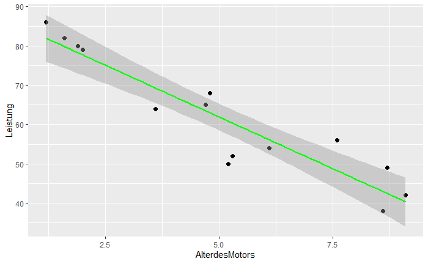

```r
library(ggplot2)#->Diagramme

ggplot(uebung3, aes(x = AlterdesMotors, y = Leistung)) + geom_point(size = 2) + geom_smooth(method = "lm", col = "green")
```

Es besteht ein augenscheinlicher negativer linearer Zusammenhang.

# Deskriptive Statistik

```r
library(psych) #->Deskriptive Statistik
describe(uebung3)
```

|  | vars | n | mean | sd | median | trimmed | mad | min | max | range | skew | kurtosis | se |
| --- | --- | --- | --- | --- | --- | --- | --- | --- | --- | --- | --- | --- | --- |
| ID | 1 | 14 | 7.50 | 4.18 | 7.5 | 7.50 | 5.19 | 1.0 | 14.0 | 13.0 | 0.00 | -1.46 | 1.12 |
| AlterdesMotors | 2 | 14 | 5.03 | 2.75 | 5.0 | 5.01 | 4.15 | 1.2 | 9.1 | 7.9 | 0.08 | -1.50 | 0.73 |
| Leistung | 3 | 14 | 61.79 | 15.51 | 60.0 | 61.75 | 15.57 | 38.0 | 86.0 | 48.0 | 0.14 | -1.46 | 4.14 |

# Korrelation nach Spearman

Der Korrelationskoeffizient kann nur Werte im Bereich zwischen -1 und +1 annehmen. Ist er kleiner als Null (r < 0), so besteht ein negativer linearer Zusammenhang. Bei einem Wert grösser als Null (r > 0) besteht ein positiver linearer Zusammenhang und bei einem Wert von Null (r = 0) besteht kein Zusammenhang zwischen den Variablen.

```r
test1 <- cor.test(uebung3$Leistung, uebung3$AlterdesMotors, method = "spearman")
test1
```

[output not shown]

Die Information aus der Auswertung werden in der Varibale “test” gespeichert.

# Bestimmtheitsmaß - R²

Das Bestimmtheitsmaß, auch Determinationskoeffizient, bezeichnet mit R² ist in der Statistik eine Kennzahl zur Beurteilung der Anpassungsgüte. Das Bestimmtheitsmaß entspricht dem Quadrat des Bravais-Pearson-Korrelationskoeffizienten.

$$Bestimmtheitsmaß=Korrelationskoeffizient2∗100$$
$$Bestimmtheitsmaß=r2∗100$$

```r
rbestimmt <- (test1$estimate)^2  *100
sprintf("Bestimmtheitsmaß: %.2f Prozent",rbestimmt)
```

```
[1] "Bestimmtheitsmaß: 85.61 Prozent"
```

Zur Berechung des Bestimmtheitsmaßes wird auf die Varibale “test1” zurückgegriffen. Der Korrelationskoeffizient ist in “estimate” gespeichert.

Wird dieser Wert mit 100 multipliziert, so ergibt sich ein Prozentwert. Dieser gibt an, welcher Anteil der Varianz in beiden Variablen durch gemeinsame Varianzanteile determiniert wird. Für das vorliegende Beispiel beträgt der Anteil der gemeinsamen Varianz 85.61%.

# Effektstärke

Effektstärke (auch Effektgröße) bezeichnet die Größe eines statistischen Effekts. Sie kann zur Verdeutlichung der praktischen Relevanz von statistisch signifikanten Ergebnissen herangezogen werden. Zur Messung der Effektstärke werden unterschiedliche Effektmaße verwendet. Im Rahmen dieses Verfahrens wird die Effektstärke nach Cohen interpretiert.

```r
sprintf("Effektstärke: %.2f",abs(test1$estimate))
```

```
[1] "Effektstärke: 0.93"
```

|r| = .10 entspricht einem schwachen Effekt

|r| = .30 entspricht einem mittleren Effekt

|r| = .50 entspricht einem starken Effekt

Das Ergebnis ist stark nach Cohen(1992).

# Aussage

Das Alter und die Leistung der Motoren korrelieren hochsignifikant (rho = -0.925, p = .000, n = 14). Je hoeher das Alter eines Motors, desto schlechter ist die Leistung. 85.61% der Streuung der gemeinsamen Varianz kann durch Alter und Leistung der Motoren erklaert werden (Bestimmtheitsmass). Dabei handelt es sich nach Cohen (1992) um einen starken Effekt.

H0 kann verworfen werden. “Es gibt keinen linearen Zusammenhang zwischen den ordinalskalierten Variablen Alter und Leistung von Motoren.”